# Final Project

Abdulrazzag M. Falah

May 7, 2018

Using Trends in International Mathematics and Science Study (TIMSS) Data in Predicting Yemeni Students’ Math and Science Achievement

Abdulrazzag M. Falah  
University of Kansas, Lawrence, KS 66046, USA

Submitted in partail fulfillment of POLS 909: May 12, 2018

**Introduction**

The current structure of Yemen’s formal education system has been in place since North and South Yemen were unified in 1990. Formal education currently encompasses nine years of compulsory Basic Education (Grades 1-9) followed by three years of General Secondary Education of which the first year, Grade 10, is general (i.e., all students study all curriculum subjects). From Grade 11 on, students choose between two tracks: Literary or Scienti!c. Literary students study humanities subjects. Students in the Scienti!c track study biology, chemistry, mathematics, and physics in addition to the common subjects. Students in both tracks study Quran sciences, Islamic education, Arabic, and English. In lieu of General Secondary Education, a two- to three-year Post-basic Technical Vocational Education and Training (TVET) track also is offered.

Students achievement in mathematics and science is an important proxy in their overall future school performance.

**Goals and Objectives**

**Independent Variables:** Studnet demographical information, such as gender, family background, *economic affluency and economic disadvantageness*.

**Group Identifier:** Schools

**Research questions and hypotheses**

1. Does the economic status of the student’s achievement in math and science? If so to what extent?  
   2. Is gender a significant predictor of student achievement in math and/or science?  
   Hypotheses:
2. The economic status negatively affects the student’s achievement in math and science.
3. There is a significant difference between males and females in math and science achievement.  
   Below is an initial analysis of what the data looks like.

```r
#rm(list=ls())
list.of.packages <- c("foreign", "lme4", "sjstats", "ggplot2", "lattice", "rockchalk", "stargazer", "brms")
new.packages <- list.of.packages[!(list.of.packages %in% installed.packages()[,"Package"])]
if(length(new.packages)) install.packages(new.packages)
lapply(list.of.packages, require, character.only=TRUE)
```

```
##  Hlavac, Marek (2015). stargazer: Well-Formatted Regression and Summary Statistics Tables.
```

```
##  R package version 5.2. http://CRAN.R-project.org/package=stargazer
```

```
## Loading 'brms' package (version 2.0.1). Useful instructions
## can be found by typing help('brms'). A more detailed introduction
## to the package is available through vignette('brms_overview').
## Run theme_set(theme_default()) to use the default bayesplot theme.
```

[output not shown]

```r
YemenData <- read.spss("C:\\Users\\Abdulrazzag\\Desktop\\TIMSS Yemen\\Merged Data\\Yemen2007.sav", to.data.frame = TRUE)
```

```
## re-encoding from UTF-8
```

```r
YemenData$IDSCHOOL <- as.factor(YemenData$IDSCHOOL)
```

### Number of Schools and students within them

```r
#Calculate the number of students in every school
freq.school <- as.data.frame(table(unique(YemenData)$IDSCHOOL))
#Number of schools
length(levels(YemenData$IDSCHOOL))
```

```
## [1] 144
```

```r
#Exclude schools with less than 30 students
schools <- freq.school[which(freq.school$Freq>30 & freq.school$Freq!=0),]
#Exclude the schools with less than 30 students from the dataframe
YemenData.filtered <- subset(YemenData,IDSCHOOL %in% schools$Var1)
#Check if the code worked by comparing the two vectors of school IDs
identical(unique(schools$Var1), unique(YemenData.filtered$IDSCHOOL))
```

```
## [1] TRUE
```

```r
colnames(YemenData.filtered)[762] <- "ECONOMIC_DISADVANTAGE"
colnames(YemenData.filtered)[763] <- "ECONOMIC_AFFLUENCY"

cat("Original number of schools is:", length(unique(YemenData$IDSCHOOL)))
```

```
## Original number of schools is: 144
```

```r
cat("\n")
```

```r
cat( "New number of schools is:", length(unique(YemenData.filtered$IDSCHOOL)))
```

```
## New number of schools is: 121
```

```r
# final.data <- YemenData.filtered[,c("IDSCHOOL", "IDSTUD", "IDTEACH", "ASMMAT01", "ASSSCI01", "AC4GSBED")]
# colnames(final.data) <- paste0(c("IDSCHOOL", "IDSTUD", "IDTEACH", "ASMMAT01", "ASSSCI01"))
# YemenData.Reshaped <- reshape(final.data, varying = list(c("ASMMAT01", "ASSSCI01")), timevar = "IDSCHOOL", idvar = c("IDSTUD", "IDTEACH"), direction = 'long', sep="")
# colnames(YemenData.Reshaped) <- paste0(c("IDSCHOOL", "IDSTUD", "IDTEACH", "AC4GSBED", "ASMMAT01"))
#
#head(YemenData.filtered)
```

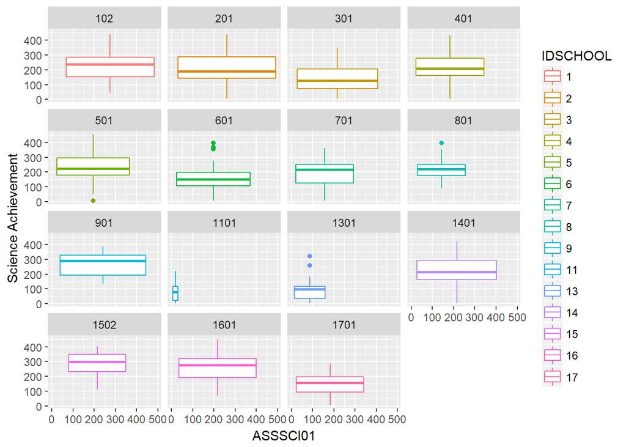

```r
ggplot(YemenData[as.numeric(YemenData$IDSCHOOL)<=15,], aes(x=ASSSCI01,y=ASMMAT03, color=IDSCHOOL)) +
  geom_boxplot() +
  facet_wrap(~IDCLASS)+
  ylab("Science Achievement")
```

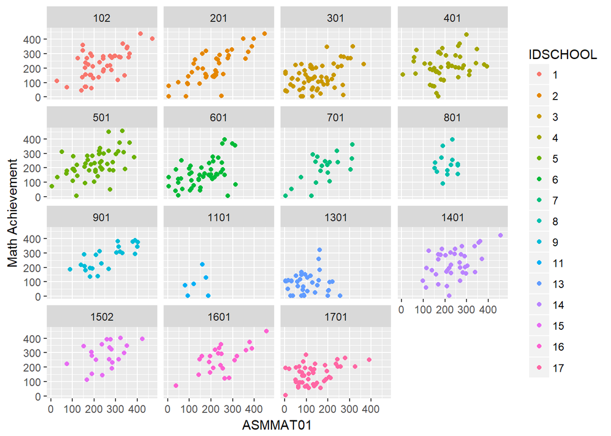

```r
ggplot(YemenData[as.numeric(YemenData$IDSCHOOL)<=15,], aes(x=ASMMAT01,y=ASMMAT03, color=IDSCHOOL)) +
  geom_point() +
  facet_wrap(~IDCLASS)+
  ylab("Math Achievement")
```

###Frequencies

```r
cat("Percentage of students by sex:", "\n")
```

```
## Percentage of students by sex:
```

```r
prop.table(table(YemenData.filtered$ITSEX))
```

```
##
##      GIRL       BOY
## 0.4531473 0.5468527
```

```r
cat("\n")
```

```r
cat("Percentage of ECONOMIC_AFFLUENCY")
```

```
## Percentage of ECONOMIC_AFFLUENCY
```

```r
cat("\n")
```

```r
prop.table(table(YemenData.filtered$ECONOMIC_AFFLUENCY))
```

```
##
##      0 TO 10 PERCENT     11 TO 25 PERCENT     26 TO 50 PERCENT
##           0.45638391           0.31099694           0.21917359
## MORE THAN 50 PERCENT
##           0.01344556
```

```r
cat("\n")
```

```r
cat("Percentage of ECONOMIC_DISADVANTAGE")
```

```
## Percentage of ECONOMIC_DISADVANTAGE
```

```r
cat("\n")
```

```r
prop.table(table(YemenData.filtered$ECONOMIC_DISADVANTAGE))
```

```
##
##      0 TO 10 PERCENT     11 TO 25 PERCENT     26 TO 50 PERCENT
##            0.0330179            0.1184941            0.2189879
## MORE THAN 50 PERCENT
##            0.6295001
```

### LME4 Models

In the following chunk of code, I created an intercept-only model, model0, and two models for both math achievement, model1, and science achievement, model2.

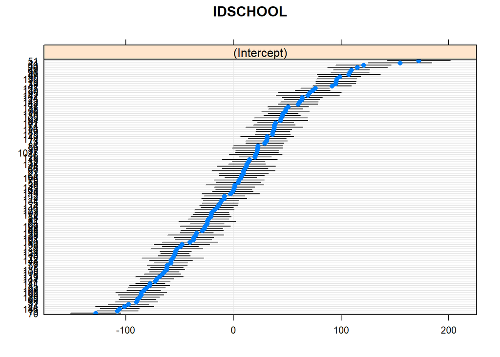

```r
model0 <- lmer(ASMMAT01 ~ (1|IDSCHOOL), data = YemenData.filtered)

model1 <- lmer( ASMMAT01~ ECONOMIC_DISADVANTAGE + ECONOMIC_AFFLUENCY + ITSEX + (1|IDSCHOOL), data = YemenData.filtered)
model2 <- lmer( ASSSCI01~ ECONOMIC_DISADVANTAGE + ECONOMIC_AFFLUENCY + ITSEX + (1|IDSCHOOL), data = YemenData.filtered)

msss <- ranef(model1, condVar=TRUE)
dotplot(msss)
```

### Intraclass Correlation Coefficient

```r
cat("The Intraclass Correlation is:")
```

```
## The Intraclass Correlation is:
```

```r
icc(model0)
```

```
## Linear mixed model
##  Family: gaussian (identity)
## Formula: ASMMAT01 ~ (1 | IDSCHOOL)
##
##   ICC (IDSCHOOL): 0.356449
```

As shown above, the intraclass correlation coefficient shows that approximately 36% of the variance in the data in attributed to group differences. This is an indicator that a normal linear regression will not account for all the residuals in the variables and that a multilevel approach is strongly advised.

```r
summary(model1)
```

```
## Linear mixed model fit by REML ['lmerMod']
## Formula: ASMMAT01 ~ ECONOMIC_DISADVANTAGE + ECONOMIC_AFFLUENCY + ITSEX +
##     (1 | IDSCHOOL)
##    Data: YemenData.filtered
##
## REML criterion at convergence: 106941.5
##
## Scaled residuals:
##     Min      1Q  Median      3Q     Max
## -3.0136 -0.7043 -0.0359  0.6779  3.3455
##
## Random effects:
##  Groups   Name        Variance Std.Dev.
##  IDSCHOOL (Intercept) 4223     64.99
##  Residual             7612     87.25
## Number of obs: 9052, groups:  IDSCHOOL, 111
##
## Fixed effects:
##                                           Estimate Std. Error t value
## (Intercept)                               248.7188    43.0149   5.782
## ECONOMIC_DISADVANTAGE11 TO 25 PERCENT     -34.5896    42.5606  -0.813
## ECONOMIC_DISADVANTAGE26 TO 50 PERCENT     -46.6411    43.4869  -1.073
## ECONOMIC_DISADVANTAGEMORE THAN 50 PERCENT -36.6844    42.3566  -0.866
## ECONOMIC_AFFLUENCY11 TO 25 PERCENT         25.9220    15.3248   1.692
## ECONOMIC_AFFLUENCY26 TO 50 PERCENT         -0.2786    19.5649  -0.014
## ECONOMIC_AFFLUENCYMORE THAN 50 PERCENT     26.8906    49.5883   0.542
## ITSEXBOY                                    4.0164     2.9273   1.372
##
## Correlation of Fixed Effects:
##                           (Intr) ECONOMIC_DT2P ECONOMIC_DISADVANTAGE2T5P
## ECONOMIC_DT2P             -0.867
## ECONOMIC_DISADVANTAGE2T5P -0.905  0.841
## ECONOMIC_DISADVANTAGEMT5P -0.974  0.873         0.916
## ECONOMIC_AT2P             -0.243  0.076        -0.028
## ECONOMIC_AFFLUENCY2T5P    -0.300 -0.012         0.120
## ECONOMIC_AFFLUENCYMT5P    -0.618  0.466         0.544
## ITSEXBOY                  -0.050  0.017         0.006
##                           ECONOMIC_DISADVANTAGEMT5P ECONOMIC_AT2P
## ECONOMIC_DT2P
## ECONOMIC_DISADVANTAGE2T5P
## ECONOMIC_DISADVANTAGEMT5P
## ECONOMIC_AT2P              0.121
## ECONOMIC_AFFLUENCY2T5P     0.217                     0.385
## ECONOMIC_AFFLUENCYMT5P     0.595                     0.188
## ITSEXBOY                   0.008                     0.040
##                           ECONOMIC_AFFLUENCY2T5P ECONOMIC_AFFLUENCYMT5P
## ECONOMIC_DT2P
## ECONOMIC_DISADVANTAGE2T5P
## ECONOMIC_DISADVANTAGEMT5P
## ECONOMIC_AT2P
## ECONOMIC_AFFLUENCY2T5P
## ECONOMIC_AFFLUENCYMT5P     0.263
## ITSEXBOY                   0.005                  0.018
```

```r
summary(model2)
```

```
## Linear mixed model fit by REML ['lmerMod']
## Formula: ASSSCI01 ~ ECONOMIC_DISADVANTAGE + ECONOMIC_AFFLUENCY + ITSEX +
##     (1 | IDSCHOOL)
##    Data: YemenData.filtered
##
## REML criterion at convergence: 109921.1
##
## Scaled residuals:
##     Min      1Q  Median      3Q     Max
## -2.8341 -0.7393 -0.0918  0.6591  3.8430
##
## Random effects:
##  Groups   Name        Variance Std.Dev.
##  IDSCHOOL (Intercept)  6212     78.82
##  Residual             10576    102.84
## Number of obs: 9052, groups:  IDSCHOOL, 111
##
## Fixed effects:
##                                           Estimate Std. Error t value
## (Intercept)                                263.242     52.128   5.050
## ECONOMIC_DISADVANTAGE11 TO 25 PERCENT      -72.402     51.578  -1.404
## ECONOMIC_DISADVANTAGE26 TO 50 PERCENT      -82.697     52.704  -1.569
## ECONOMIC_DISADVANTAGEMORE THAN 50 PERCENT  -79.246     51.334  -1.544
## ECONOMIC_AFFLUENCY11 TO 25 PERCENT          31.794     18.572   1.712
## ECONOMIC_AFFLUENCY26 TO 50 PERCENT           4.401     23.713   0.186
## ECONOMIC_AFFLUENCYMORE THAN 50 PERCENT      11.014     60.082   0.183
## ITSEXBOY                                     4.086      3.453   1.183
##
## Correlation of Fixed Effects:
##                           (Intr) ECONOMIC_DT2P ECONOMIC_DISADVANTAGE2T5P
## ECONOMIC_DT2P             -0.867
## ECONOMIC_DISADVANTAGE2T5P -0.905  0.841
## ECONOMIC_DISADVANTAGEMT5P -0.974  0.873         0.916
## ECONOMIC_AT2P             -0.243  0.076        -0.028
## ECONOMIC_AFFLUENCY2T5P    -0.300 -0.012         0.120
## ECONOMIC_AFFLUENCYMT5P    -0.618  0.466         0.544
## ITSEXBOY                  -0.049  0.016         0.006
##                           ECONOMIC_DISADVANTAGEMT5P ECONOMIC_AT2P
## ECONOMIC_DT2P
## ECONOMIC_DISADVANTAGE2T5P
## ECONOMIC_DISADVANTAGEMT5P
## ECONOMIC_AT2P              0.121
## ECONOMIC_AFFLUENCY2T5P     0.217                     0.385
## ECONOMIC_AFFLUENCYMT5P     0.595                     0.188
## ITSEXBOY                   0.008                     0.039
##                           ECONOMIC_AFFLUENCY2T5P ECONOMIC_AFFLUENCYMT5P
## ECONOMIC_DT2P
## ECONOMIC_DISADVANTAGE2T5P
## ECONOMIC_DISADVANTAGEMT5P
## ECONOMIC_AT2P
## ECONOMIC_AFFLUENCY2T5P
## ECONOMIC_AFFLUENCYMT5P     0.263
## ITSEXBOY                   0.005                  0.018
```

```r
# cat("\n")
# levels(YemenData.filtered$ECONOMIC_DISADVAntage)
# levels(YemenData.filtered$ECONOMIC_AFFLUENCY)
# cat("Math Achievement model")
stargazer(model1,type ="text", p.auto = TRUE)
```

```
##
## =====================================================================
##                                               Dependent variable:
##                                           ---------------------------
##                                                    ASMMAT01
## ---------------------------------------------------------------------
## ECONOMIC_DISADVANTAGE11 TO 25 PERCENT               -34.590
##                                                    (42.561)
##
## ECONOMIC_DISADVANTAGE26 TO 50 PERCENT               -46.641
##                                                    (43.487)
##
## ECONOMIC_DISADVANTAGEMORE THAN 50 PERCENT           -36.684
##                                                    (42.357)
##
## ECONOMIC_AFFLUENCY11 TO 25 PERCENT                  25.922*
##                                                    (15.325)
##
## ECONOMIC_AFFLUENCY26 TO 50 PERCENT                  -0.279
##                                                    (19.565)
##
## ECONOMIC_AFFLUENCYMORE THAN 50 PERCENT              26.891
##                                                    (49.588)
##
## ITSEXBOY                                             4.016
##                                                     (2.927)
##
## Constant                                          248.719***
##                                                    (43.015)
##
## ---------------------------------------------------------------------
## Observations                                         9,052
## Log Likelihood                                    -53,470.760
## Akaike Inf. Crit.                                 106,961.500
## Bayesian Inf. Crit.                               107,032.600
## =====================================================================
## Note:                                     *p<0.1; **p<0.05; ***p<0.01
```

```r
# cat("Science Achievement model")
stargazer(model2,type ="text", p.auto = TRUE)
```

```
##
## =====================================================================
##                                               Dependent variable:
##                                           ---------------------------
##                                                    ASSSCI01
## ---------------------------------------------------------------------
## ECONOMIC_DISADVANTAGE11 TO 25 PERCENT               -72.402
##                                                    (51.578)
##
## ECONOMIC_DISADVANTAGE26 TO 50 PERCENT               -82.697
##                                                    (52.704)
##
## ECONOMIC_DISADVANTAGEMORE THAN 50 PERCENT           -79.246
##                                                    (51.334)
##
## ECONOMIC_AFFLUENCY11 TO 25 PERCENT                  31.794*
##                                                    (18.572)
##
## ECONOMIC_AFFLUENCY26 TO 50 PERCENT                   4.401
##                                                    (23.713)
##
## ECONOMIC_AFFLUENCYMORE THAN 50 PERCENT              11.014
##                                                    (60.082)
##
## ITSEXBOY                                             4.086
##                                                     (3.453)
##
## Constant                                          263.242***
##                                                    (52.128)
##
## ---------------------------------------------------------------------
## Observations                                         9,052
## Log Likelihood                                    -54,960.560
## Akaike Inf. Crit.                                 109,941.100
## Bayesian Inf. Crit.                               110,012.200
## =====================================================================
## Note:                                     *p<0.1; **p<0.05; ***p<0.01
```

```r
# table1<- outreg(model1, type = "html")
# cat(table1)
```

```r
confint(model1)
```

```
## Computing profile confidence intervals ...
```

```
##                                                 2.5 %     97.5 %
## .sig01                                      55.094148  72.388656
## .sigma                                      85.981752  88.539791
## (Intercept)                                166.455215 331.029228
## ECONOMIC_DISADVANTAGE11 TO 25 PERCENT     -116.010641  46.823714
## ECONOMIC_DISADVANTAGE26 TO 50 PERCENT     -129.812737  36.559782
## ECONOMIC_DISADVANTAGEMORE THAN 50 PERCENT -117.708517  44.340362
## ECONOMIC_AFFLUENCY11 TO 25 PERCENT          -3.411267  55.221250
## ECONOMIC_AFFLUENCY26 TO 50 PERCENT         -37.702115  37.146680
## ECONOMIC_AFFLUENCYMORE THAN 50 PERCENT     -67.986709 121.758162
## ITSEXBOY                                    -1.839272   9.659041
```

```r
confint(model2)
```

```
## Computing profile confidence intervals ...
```

```
##                                                 2.5 %    97.5 %
## .sig01                                      66.852457  87.77710
## .sigma                                     101.346272 104.36138
## (Intercept)                                163.533366 362.98430
## ECONOMIC_DISADVANTAGE11 TO 25 PERCENT     -171.075412  26.27024
## ECONOMIC_DISADVANTAGE26 TO 50 PERCENT     -183.495093  18.15101
## ECONOMIC_DISADVANTAGEMORE THAN 50 PERCENT -177.442952  18.96087
## ECONOMIC_AFFLUENCY11 TO 25 PERCENT          -3.757090  67.30213
## ECONOMIC_AFFLUENCY26 TO 50 PERCENT         -40.957227  49.76655
## ECONOMIC_AFFLUENCYMORE THAN 50 PERCENT    -103.941948 125.96792
## ITSEXBOY                                    -2.789179  10.76092
```

To make sure of the results, I ran the confidence intervals of both models and saw that all of them include zero, which helps us conclude that these predictors are not significant. Stopping with this analysis, I decided to use the ‘brms’ package to run a multivariate multilevel analysis. The results are shown below and not very different from the LME4.

```r
fit1 <- brm(cbind(ASMMAT01, ASSSCI01) ~ ECONOMIC_DISADVANTAGE + ECONOMIC_AFFLUENCY + ITSEX + (1|p|IDSCHOOL), data = YemenData.filtered, thin=10, chains = 3, cores = 4)
```

```
## Setting 'rescor' to TRUE by default for this combination of families
```

```r
add_ic(fit1) <- "loo"
summary(fit1)
```

```
##  Family: MV(gaussian, gaussian)
##   Links: mu = identity; sigma = identity
##          mu = identity; sigma = identity
## Formula: ASMMAT01 ~ ECONOMIC_DISADVANTAGE + ECONOMIC_AFFLUENCY + ITSEX + (1 | p | IDSCHOOL)
##          ASSSCI01 ~ ECONOMIC_DISADVANTAGE + ECONOMIC_AFFLUENCY + ITSEX + (1 | p | IDSCHOOL)
##    Data: YemenData.filtered (Number of observations: 9052)
## Samples: 3 chains, each with iter = 2000; warmup = 1000; thin = 10;
##          total post-warmup samples = 300
##     ICs: LOO = 211316.29; WAIC = NA; R2 = NA
##
## Group-Level Effects:
## ~IDSCHOOL (Number of levels: 111)
##                                            Estimate Est.Error l-95% CI
## sd(ASMMAT01_Intercept)                        65.16      4.62    57.12
## sd(ASSSCI01_Intercept)                        79.15      5.54    69.48
## cor(ASMMAT01_Intercept,ASSSCI01_Intercept)     0.96      0.01     0.94
##                                            u-95% CI Eff.Sample Rhat
## sd(ASMMAT01_Intercept)                        75.16        294 1.00
## sd(ASSSCI01_Intercept)                        91.32        257 1.00
## cor(ASMMAT01_Intercept,ASSSCI01_Intercept)     0.98        300 1.00
##
## Population-Level Effects:
##                                                 Estimate Est.Error
## ASMMAT01_Intercept                                246.04     42.84
## ASSSCI01_Intercept                                259.41     51.72
## ASMMAT01_ECONOMIC_DISADVANTAGE11TO25PERCENT       -34.09     42.12
## ASMMAT01_ECONOMIC_DISADVANTAGE26TO50PERCENT       -45.02     43.86
## ASMMAT01_ECONOMIC_DISADVANTAGEMORETHAN50PERCENT   -34.92     42.65
## ASMMAT01_ECONOMIC_AFFLUENCY11TO25PERCENT           27.31     15.21
## ASMMAT01_ECONOMIC_AFFLUENCY26TO50PERCENT            2.98     20.28
## ASMMAT01_ECONOMIC_AFFLUENCYMORETHAN50PERCENT       27.40     50.55
## ASMMAT01_ITSEXBOY                                   3.50      2.87
## ASSSCI01_ECONOMIC_DISADVANTAGE11TO25PERCENT       -71.53     50.03
## ASSSCI01_ECONOMIC_DISADVANTAGE26TO50PERCENT       -79.69     53.44
## ASSSCI01_ECONOMIC_DISADVANTAGEMORETHAN50PERCENT   -77.03     51.37
## ASSSCI01_ECONOMIC_AFFLUENCY11TO25PERCENT           32.45     18.70
## ASSSCI01_ECONOMIC_AFFLUENCY26TO50PERCENT            8.37     24.28
## ASSSCI01_ECONOMIC_AFFLUENCYMORETHAN50PERCENT       11.51     61.58
## ASSSCI01_ITSEXBOY                                   5.22      3.39
##                                                 l-95% CI u-95% CI
```

[output cut: 32 more lines]

```
## ASSSCI01_ITSEXBOY                                      287 1.00
##
## Family Specific Parameters:
##                           Estimate Est.Error l-95% CI u-95% CI Eff.Sample
## sigma_ASMMAT01               87.25      0.65    86.06    88.49        300
## sigma_ASSSCI01              102.84      0.76   101.27   104.29        300
## rescor(ASMMAT01,ASSSCI01)     0.65      0.01     0.64     0.66        300
##                           Rhat
## sigma_ASMMAT01            1.00
## sigma_ASSSCI01            1.00
## rescor(ASMMAT01,ASSSCI01) 0.99
##
## Samples were drawn using sampling(NUTS). For each parameter, Eff.Sample
## is a crude measure of effective sample size, and Rhat is the potential
## scale reduction factor on split chains (at convergence, Rhat = 1).
```

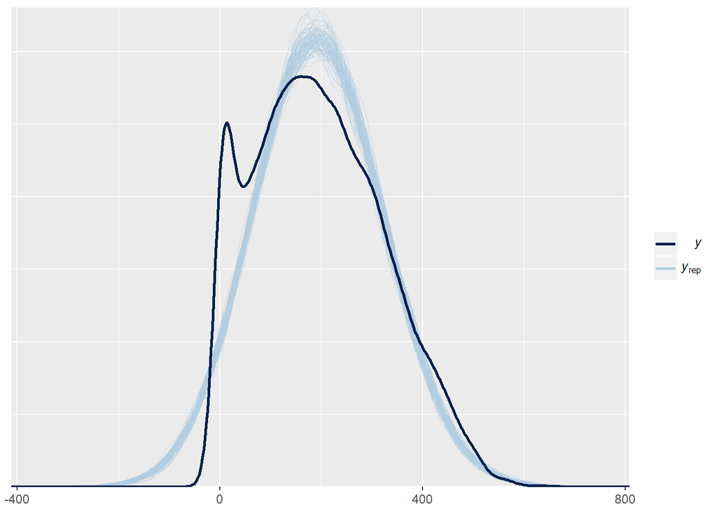

```r
pp_check(fit1, resp = "ASSSCI01", nsamples = 100)
```

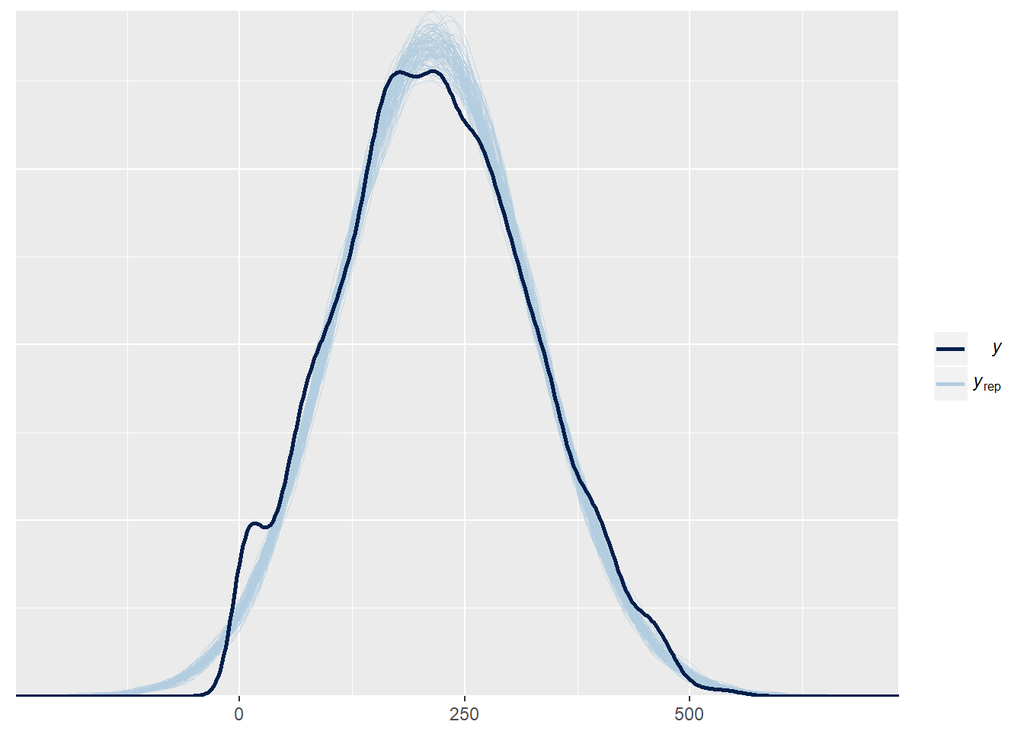

```r
pp_check(fit1, resp = "ASMMAT01", nsamples = 100)
```

```r
bayes_R2(fit1)
```

```
##              Estimate   Est.Error   2.5%ile  97.5%ile
## R2_ASMMAT01 0.3248236 0.006749861 0.3100591 0.3368152
## R2_ASSSCI01 0.3395681 0.006739528 0.3259846 0.3518558
```